# LogisticRegression_Income

```python
data.tail()
```

|  | Age | Workclass | Sector | Education | Education-Num | Marital-Status | Occupation | Relationship | Race | Sex | Hours per week | Native-Country | y |
| --- | --- | --- | --- | --- | --- | --- | --- | --- | --- | --- | --- | --- | --- |
| 32556 | 27 | Private | 257302 | Assoc-acdm | 12 | Married-civ-spouse | Tech-support | Wife | White | Female | 38 | United-States | <=50K |
| 32557 | 40 | Private | 154374 | HS-grad | 9 | Married-civ-spouse | Machine-op-inspct | Husband | White | Male | 40 | United-States | >50K |
| 32558 | 58 | Private | 151910 | HS-grad | 9 | Widowed | Adm-clerical | Unmarried | White | Female | 40 | United-States | <=50K |
| 32559 | 22 | Private | 201490 | HS-grad | 9 | Never-married | Adm-clerical | Own-child | White | Male | 20 | United-States | <=50K |
| 32560 | 52 | Self-emp-inc | 287927 | HS-grad | 9 | Married-civ-spouse | Exec-managerial | Wife | White | Female | 40 | United-States | >50K |

We also notice from our dataset that there are many categorical attributes so we encode them into numerical.

```python
#Create Dummy Variables to encode categorical variables into numerical variables
data_workclass = pd.get_dummies(data['Workclass'])
data_marital_status = pd.get_dummies(data['Marital-Status'])
data_occupation = pd.get_dummies(data['Occupation'])
data_relationship = pd.get_dummies(data['Relationship'])
data_race = pd.get_dummies(data['Race'])
data_gender = pd.get_dummies(data['Sex'])
data_country = pd.get_dummies(data['Native-Country'])
```

```python
#Create a data Frame from Encoded Variables
data_encoded = pd.concat([data_workclass,data_marital_status,data_occupation,data_relationship,data_race,data_gender,data_country],axis=1)
```

```python
#Extract numerical data from the imported dataset
data_numeric = data[['Age','Sector','Education-Num','Hours per week']]
```

```python
data_numeric.head()
```

|  | Age | Sector | Education-Num | Hours per week |
| --- | --- | --- | --- | --- |
| 0 | 39 | 77516 | 13 | 40 |
| 1 | 50 | 83311 | 13 | 13 |
| 2 | 38 | 215646 | 9 | 40 |
| 3 | 53 | 234721 | 7 | 40 |
| 4 | 28 | 338409 | 13 | 40 |

```python
#Combine Enconded Data and Numerical Data into a Final Dataset
data_final = pd.concat([data_encoded,data_numeric],axis=1)
```

```python
#Convert y variable into a binary outcome (do they make over 50k or not)
def get_y(y):
    if y.find("<=")>-1:
        return 0
    else:
        return 1
```

Now the data is processed, we can train a model and evaluate its performance

```python
#X are predictors and y is target variable
X = data_final
y = data['y'].apply(lambda y: get_y(y))
```

```python
#Apply Standard Scaler because attribute values are not
#in the same range
from sklearn.preprocessing import StandardScaler
sc = StandardScaler()
X[['Age','Sector','Education-Num','Hours per week']] = sc.fit_transform(X[['Age','Sector','Education-Num','Hours per week']])
```

```python
#Split data into train set and test set
from sklearn.model_selection import train_test_split
X_train, X_test, y_train, y_test = train_test_split(X,y, test_size = 0.3, random_state=0)
#Build a Logistic Regression model
from sklearn.linear_model import LogisticRegression
model = LogisticRegression()
model.fit(X_train, y_train)
```

```
LogisticRegression(C=1.0, class_weight=None, dual=False, fit_intercept=True,
          intercept_scaling=1, max_iter=100, multi_class='warn',
          n_jobs=None, penalty='l2', random_state=None, solver='warn',
          tol=0.0001, verbose=0, warm_start=False)
```

```python
#Predict the values with test set
y_pred = model.predict(X_test)
print("Score value: ", model.score(X_train,y_train))
```

```
Score value:  0.8379255879255879
```

The high value of score indicates that this Logislic Regression is a good model

```
Predicted     0     1   All
Actual
0          6804   603  7407
1          1023  1339  2362
All        7827  1942  9769
Predicted         0         1       All
Actual
0          0.459295  0.127646  0.379107
1          0.069056  0.283446  0.120893
All        0.528352  0.411092  0.500000
```

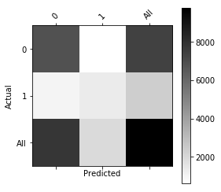

```python
#Compute a confusion matrix to evaluate model performance
from sklearn.metrics import confusion_matrix
df_confusion = pd.crosstab(y_test, y_pred)
df_confusion = pd.crosstab(y_test, y_pred, rownames=['Actual'], colnames=['Predicted'], margins=True)
print(df_confusion)
df_conf_norm = df_confusion/df_confusion.sum(axis=1)
print(df_conf_norm)
import matplotlib as mpl
def plot_confusion_matrix(df_confusion, title='Confusion matrix', cmap=plt.cm.gray_r):
    plt.matshow(df_confusion, cmap=cmap) #imshow
    #plt.title(title)
    plt.colorbar()
    tick_marks = np.arange(len(df_confusion.columns))
    plt.xticks(tick_marks,df_confusion.columns, rotation=45)
    plt.yticks(tick_marks, df_confusion.index)
    #plt.tight_layout()
    plt.ylabel(df_confusion.index.name)
    plt.xlabel(df_confusion.columns.name)
plot_confusion_matrix(df_confusion)
```

```python
#Calculate confusion matrix precision
confusion_matrix(y_test, y_pred)
def precision_recall(y_test, y_pred):
    cm = confusion_matrix(y_test, y_pred)
    tp = cm[0,0]
    fp = cm[0,1]
    fn = cm[1,0]
    prec = tp / (tp+fp)
    rec = tp / (tp+fn)
    return prec, rec
precision, recall = precision_recall(y_test, y_pred)
print('Precision: %f Recall %f' % (precision, recall))
```

```
Precision: 0.918591 Recall 0.869299
```

The precision is 0.918591. We can evaluate that the Logistic Regression model is good for prediction.

```
Are under the ROC curve:  0.742741493246142
```

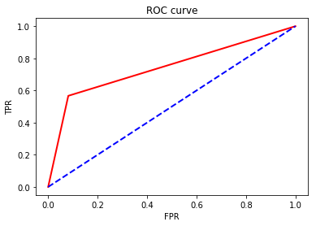

```python
#AUC and ROC curve to evaluate model performance
from sklearn.metrics import roc_curve, roc_auc_score
##Computing false and true positive rates
fpr, tpr,_=roc_curve(y_test,y_pred,drop_intermediate=False)
score = roc_auc_score(y_test,y_pred)
print("Are under the ROC curve: ", score)
plt.figure()
##Adding the ROC
plt.plot(fpr, tpr, color='red',lw=2, label='ROC curve')
##Random FPR and TPR
plt.plot([0, 1], [0, 1], color='blue', lw=2, linestyle='--')
##Title and label
plt.xlabel('FPR')
plt.ylabel('TPR')
plt.title('ROC curve')
plt.show()
```

The true positive rate evaluation results also indicate a good model

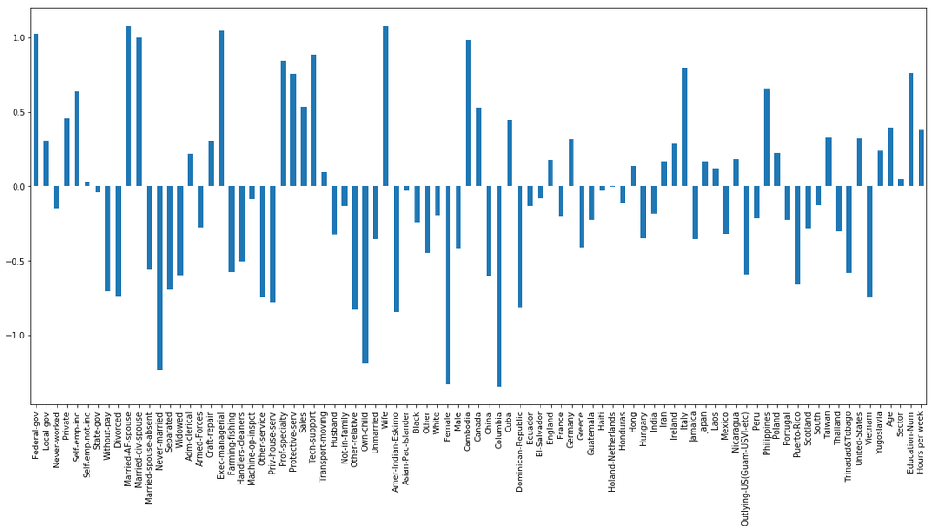

```python
plt.figure(figsize=(20,20))
plt.subplot(2,1,1)
coefs = pd.Series(model.coef_[0], index=X_train.columns)
coefs.sort_values()
coefs.plot(kind="bar")
plt.show()
```